# Statistical Analysis of Random Distribution in M&M Packages

Yoni 16 03, 2026

# Intro

### Objective of Simulation

This simulation explores the fairness and randomness in the color distribution of M&M-style chocolate candies. Specifically, it investigates:

1. How often are M&M packs evenly distributed across all colors?
2. What’s the probability of a pack missing at least one color?
3. How do the number of candies and available colors impact that probability?

While seeing some chocolate packages, I wondered:

```
  **Can I finish a pack of M&M eating two at a time, without ever mixing colors in a bite?**
```

This playful question leads to a deeper statistical exploration of random sampling, distribution fairness, and packaging quality in candy production.

### Methodology

Since production data from [M&M](https://www.mms.com/en-us) isn’t publicly available, I simulate packages based on common retail sizes and the standard 6-color set. Each simulation randomly draws a sample of candies, assigning each a color. I repeated this process hundreds of times to analyze statistical properties across “virtual” packages.

Through this approach, I estimate the probability of:

1. Getting a perfect pack (i.e., equal counts of each color).
2. Receiving a pack missing at least one color.
3. Seeing how these probabilities change with pack size or number of available colors.

My hypothesis is that perfectly balanced packs are extremely rare, especially when six colors or more are involved. Larger packs may contain all colors more consistently but still tend to be uneven in distribution.

### Parameters

Basic parameters:

We define a “pack” as a vector of integers representing the count of each color.  
Each simulation uses random sampling with replacement to mimic real-world packaging.  
Key variables:

- `n-color`: Number of distinct colors
- `n-unit`: Total candies in the pack

```r
#parameters
n= 1000              #numbers of bags per sample
n_color= 6          #unique colors of M&M
gram= 0.91          #weight of one M&M
bag_g= 250          #common weight of M&M package
n_unit= bag_g/gram  #M&M per package
```

```
## [1] "The avarage number of lentils per color is 45.8"
```

# Creating the Sample

## General Sample

In order to test the theoretical data, I need to simulate it using customize functions. here are there:

- `Create_bag`- function to create one snack package for chosen package size and number of colors.
- `sample_MnM`- function to create n bags from the Create_bag function.

key parameters for `sample_MnM`

- `n`: Number of packages in the sample
- `x_units`: Total candies in each package
- `n_colors`: Number of distinct colors in each package

[output not shown]

## Preview Graph

Now will be creating n bugs of M&M

columns:

1. `V1:V6`- the number of lentils per color
2. `even_count`- how many evens colors there are
3. `even_evens`- are the uneven colors even
4. `low_col`- sum true if one color’s count is lower than $\frac{2}{3}$ of expected value
5. `Variance`- variance of lentils per color
6. `min`- the lowest color in each row
7. `all_even`- are all colors even

here are the first rows:

| Red | Blue | Green | Orange | Yellow | Brown | even_count | even_evens | low_col | Variance | min | all_even |
| --- | --- | --- | --- | --- | --- | --- | --- | --- | --- | --- | --- |
| 40 | 49 | 45 | 40 | 54 | 47 | 3 | FALSE | 0 | 29.37 | 40 | FALSE |
| 60 | 45 | 40 | 38 | 45 | 46 | 4 | TRUE | 0 | 59.47 | 38 | FALSE |
| 45 | 46 | 47 | 40 | 45 | 51 | 2 | TRUE | 0 | 12.67 | 40 | FALSE |
| 43 | 42 | 58 | 46 | 47 | 39 | 3 | FALSE | 0 | 43.77 | 39 | FALSE |

M&M sample random rows

I summarized the sample by color bellow

|  | Min. | 1st Qu. | Median | Mean | 3rd Qu. | Max. | Var |
| --- | --- | --- | --- | --- | --- | --- | --- |
| Red | 28 | 42 | 46 | 45.816 | 50 | 76 | 37.32 |
| Blue | 29 | 42 | 46 | 45.754 | 50 | 68 | 38.42 |
| Green | 29 | 41 | 46 | 45.844 | 50 | 66 | 40.62 |
| Orange | 24 | 41 | 46 | 45.969 | 50 | 68 | 41.99 |
| Yellow | 26 | 41 | 45 | 45.386 | 49 | 65 | 35.72 |
| Brown | 27 | 41 | 46 | 45.725 | 50 | 67 | 38.34 |

summary of all colors Distribution

Here we can see the distribution of all colors to be even and of one example color (red)

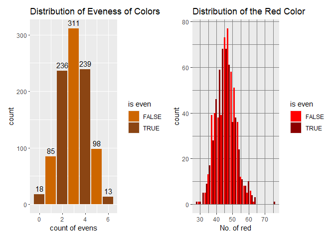

## Statistics Checking of the Simulation

### Test Expected Value

In order to see is the $\mu$ of the lentils per color are fair, I will test it per column with t.test for each color.

p.value of $H_0: \mu= \frac{n-unit}{n-color}$

```
##     Red    Blue   Green  Orange  Yellow   Brown
## "88.3%" "86.4%" "77.9%" "37.6%"  "3.4%" "74.9%"
```

Now I will do the same checking for 2 samples, to see whether there is correlation between each 2 colors distribution.

for each row i and column j

1. if i==j, this it the check from before of the expected value to n_unit/n_color
2. if i!=j, this is two samples test of same expected value hypothesis

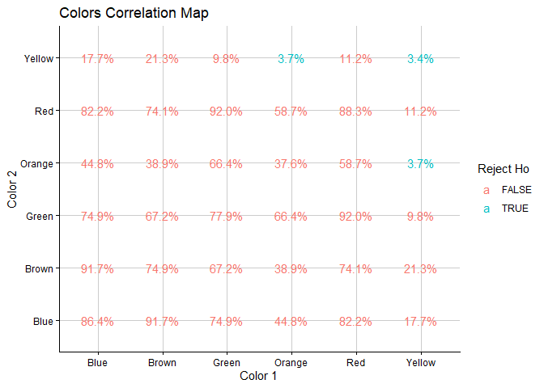

Now here Is visualization of the actual data per color

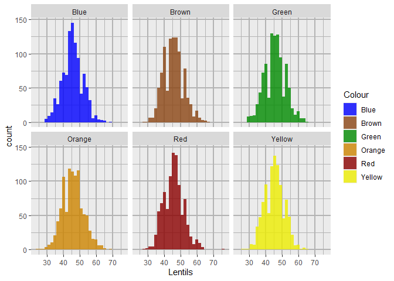

### Variance Distribution Checking

I know that the distribution of variance is approximately Gamma distribution:

$$f(x) =
\frac{1}{\Gamma(\alpha)\theta^\alpha}
x^{\alpha-1}e^{-x/\theta}$$

I can see that the variance distribution is Gamma like with shape and rate as seen below

```
## [1] "The parameters of the gamma shaped variance is shape 2.493 and scale 18.637"
```

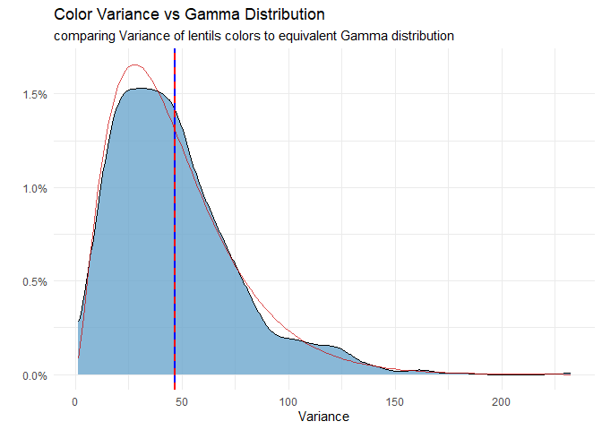

### Are All Even in the Sample?

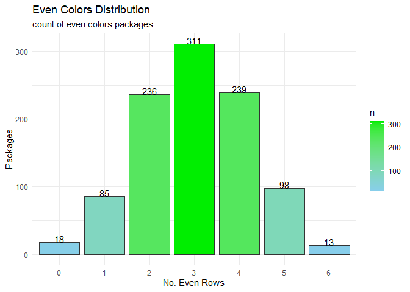

## Multiple Types of Samples

I will create a function that create sample for each number of colors and package size I want, and then calculate some interesting parameters

I will make the multiple sample. parameters:

```r
n_color<- 2:8 #Number of distinct colors in each package option
grams_op<- c(25,45,150,250,330,500,750,1000) #Weight of each package option
n_unit_op<- grams_op/gram #Total candies in each package option
nn<- 1200 #Number of packages in the sample
```

Here is some random rows:

| n_unit | n_color | even_count | even_evens | var_col | all_even | low_color | smallest_col |
| --- | --- | --- | --- | --- | --- | --- | --- |
| 1098.9 | 6 | 0.506 | 0.083 | 187.766 | 0.022 | 0.000 | 131 |
| 1098.9 | 8 | 0.498 | 0.059 | 132.436 | 0.002 | 0.000 | 102 |
| 274.7 | 6 | 0.503 | 0.085 | 42.115 | 0.018 | 0.008 | 27 |
| 824.2 | 2 | 0.491 | 0.246 | 389.284 | 0.237 | 0.000 | 369 |
| 49.5 | 2 | 0.502 | 0.253 | 26.120 | 0.255 | 0.021 | 13 |

Multiple sample example rows

### Deep Insight on the Data

Here are some insights:

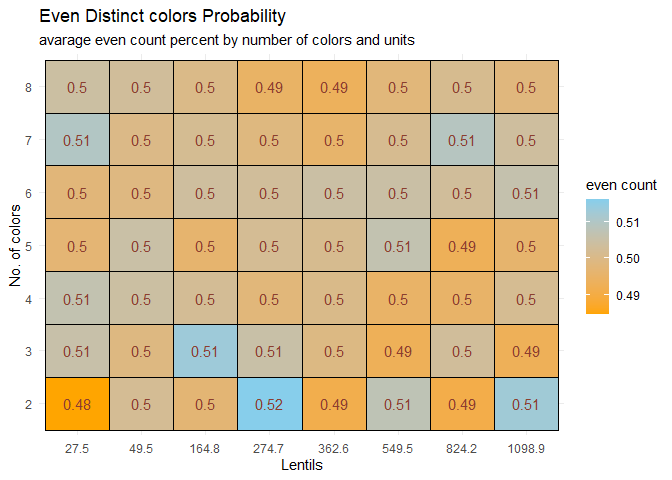

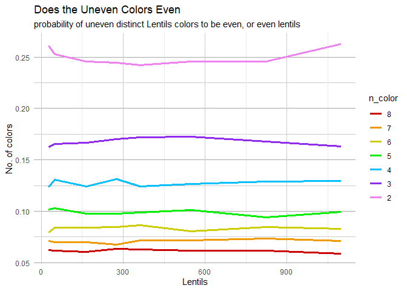

Here is probability of all even, and whether there is pattern.

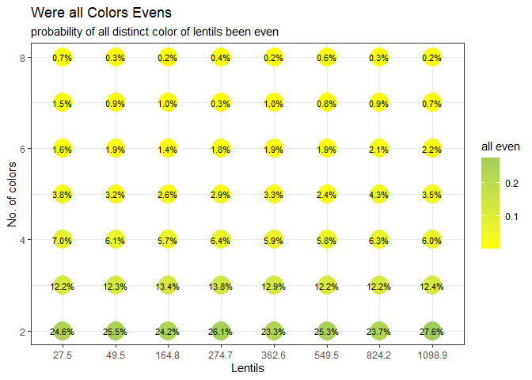

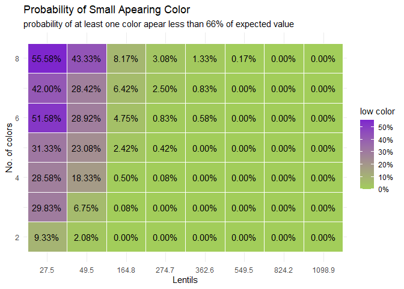

Here we can see the smallest % of Lentils in one color as seen in my sample:

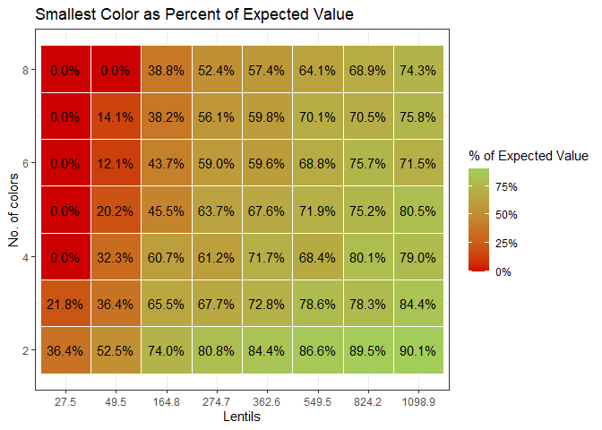

As we can see, only the small package (less than 50 lentils) have high probability of at least one color to appear severely lower.

Therefore, splitting package by color on the big ones should be relatively even.

### Using Regression for Correlation Check

I wanted to see if there is statistic correlation of the number of distinct colors of package size to the probability of all colors have equal counts of each color. as a result, I chose to check this claim with regression. Furthermore, I did the same regression adding another potential correlated parameter: the evenness of the number of distinct colors.

```
##
## ==============================================
##                       Dependent variable:
##                   ----------------------------
##                             all_even
##                        (1)            (2)
## ----------------------------------------------
## n_color              -18.764        -9.437
##                     (872.970)      (460.847)
##
## n_unit               -0.0002        -0.0002
##                      (0.0005)      (0.0005)
##
## color_No2                           11.102
##                                   (2,169.439)
##
## Constant              36.356         6.598
##                    (1,745.940)    (2,530.912)
##
## ----------------------------------------------
## Observations          2,160          2,160
## Log Likelihood       -126.634      -126.634
## Akaike Inf. Crit.    259.267        261.267
## ==============================================
## Note:              *p<0.1; **p<0.05; ***p<0.01
```

```
##
## =======================================================
##                            Dependent variable:
##                   -------------------------------------
##                   cbind(n_color, n_color - even_count)
##                          (1)                (2)
## -------------------------------------------------------
## n_color                 0.007              0.007
##                        (0.007)            (0.007)
##
## n_unit                 0.00002            0.00002
##                       (0.00005)          (0.00005)
##
## color_No2               -0.003
##                        (0.031)
##
## Constant               0.635***           0.633***
##                        (0.055)            (0.053)
##
## -------------------------------------------------------
## Observations            2,160              2,160
## Log Likelihood        -3,011.702         -3,011.708
## Akaike Inf. Crit.     6,031.404          6,029.416
## =======================================================
## Note:                       *p<0.1; **p<0.05; ***p<0.01
```

Like the previous regression, the second regression that examines the correlation of the number of colors and package size to the percentage of even numbers did not find a statistically significant correlation. In addition, visually there is no clear correlation.

[figure not shown]

# Summary

### Data Structure

The simulation created a random samples of snack packs, which was proven to be statistically random with known $\mu$ and $\sigma^2$. I created one sample with specific size and numbers of colors using “sample_MnM”, and costume multiple samples using “mega_snack”. Then, I check the relevant indicators for this project.

suggestion for any random sampler factory (like candies, Lego, toys):

1. Smaller packages need more diversity check
2. alternatively, I would recommend calculate the amount of each type in small packages

### Main Q: Eating M&M by Two

Although there is no clear pattern to the right M&M package for all the colors to have even count, different approach might find a clear reason for more or less couples of M&M. Here is what I did found:

For 2 colored pack the average is 25%, so for 2 colored marshmallow bag this will be the statistics.

See all here:

| Colors | All Even Percent |
| --- | --- |
| 2 | 25.04 |
| 3 | 12.69 |
| 4 | 6.16 |
| 5 | 3.26 |
| 6 | 1.85 |
| 7 | 0.90 |
| 8 | 0.39 |

Probability of All Colors Even by Pack Colors Number

### Conclusions

This project allowed me to implement simulation methods in response to a real (albeit silly) question, and evaluate it statistically from end to end..

I applied:

- Simulation by demand
- Exploratory analysis
- Hypothesis testing
- Distribution checks
- Outliers detection
- Visualization using R

In addition, I created the infrastructure for similar questions with different parameters to be checked in a reusable, structured way.

### Bonus: M&M Simulation

You can try to simulate a package and play here:

[the M&M Pack Simulation Game](https://yonigr94.github.io/Simulation-application-of-M-M//)

Have fun!